# SCORE: Siedner et al. (2020) replication

Data sourcing

Radoslaw Panczak

21 November, 2020

# 1 Timing of state’s measures

Data extracted from the table in supplement.

```r
# page 4 needs headers
measures_4 <- extract_tables("data-raw/supplement/2020.04.03.20052373-1.pdf",
                             pages = 4, guess = TRUE,
                             output = "data.frame") %>%
  purrr::pluck(1) %>%
  clean_names() %>%
  filter(state != "") %>%
  select(-source_s)

# some column drama
measures_8 <- extract_tables("data-raw/supplement/2020.04.03.20052373-1.pdf",
                             pages = 8, guess = FALSE,
                             output = "data.frame") %>%
  purrr::pluck(1) %>%
  clean_names() %>%
  filter(x != "") %>%
  select(- x_7) %>%
  mutate(x_6 = "")

names(measures_8) <- names(measures_4)

# these at least are consistent
for (page in c(5:7, 9:10)){

  temp  <- extract_tables("data-raw/supplement/2020.04.03.20052373-1.pdf",
                          pages = page, guess = FALSE,
                          output = "data.frame") %>%
    purrr::pluck(1) %>%
    clean_names() %>%
    filter(x != "") %>%
    select(-x_7, -x_8)

  names(temp) <- names(measures_4)

  if (page == 5) {
    measures_5_10 <- temp
  } else {
    measures_5_10 <- bind_rows(measures_5_10, temp)
  }
}

rm(temp, page)

# another drama
measures_11 <- extract_tables("data-raw/supplement/2020.04.03.20052373-1.pdf",
                              pages = 11, guess = FALSE,
                              output = "data.frame") %>%
  purrr::pluck(1) %>%
  clean_names() %>%
  filter(x != "") %>%
  select(-x_6, -x_7) %>%
  filter(word(x, 1) != "Notes:") %>%
  filter(word(x, 1) != "of") %>%
  mutate(state = word(x, end = -2),
         date = word(x, start = -1)) %>%
  select(-x) %>%
  relocate(state, date)

names(measures_11) <- names(measures_4)

# all together
measures <- bind_rows(measures_4,
                      measures_5_10,
                      measures_8,
                      measures_11) %>%
  pivot_longer(cols = a:e,
               names_to = "measure_short",
               values_to = "present") %>%
  filter(present != "") %>%
  select(-present) %>%
  mutate(date = as.Date(date, format = "%m/%d/%y")) %>%
  mutate(
    measure = case_when(
      measure_short == "a" ~ "closure of schools",
      measure_short == "b" ~ "closure of workplaces",
      measure_short == "c" ~ "cancellation of public events",
      measure_short == "d" ~ "restrictions on internal movement",
      measure_short == "e" ~ "closure of state borders"
    )) %>%
  filter(state != "Puerto Rico") %>%
  arrange(state, date)
```

Prepared dataset consists of 239 records of 51 states with measures implemented between 2020-03-10 to 2020-04-01. The dataset is in long format. The data for Puerto Rico were excluded since the preprint states that analyses were conducted for 50 states plus DC.

```r
str(measures)
```

```
## tibble [239 x 4] (S3: tbl_df/tbl/data.frame)
##  $ state        : chr [1:239] "Alabama" "Alabama" "Alabama" "Alabama" ...
##  $ date         : Date[1:239], format: "2020-03-18" "2020-03-19" ...
##  $ measure_short: chr [1:239] "a" "a" "c" "b" ...
##  $ measure      : chr [1:239] "closure of schools" "closure of schools" "cancellation of public events" "closure of workplaces" ...
```

Frequency of first measure

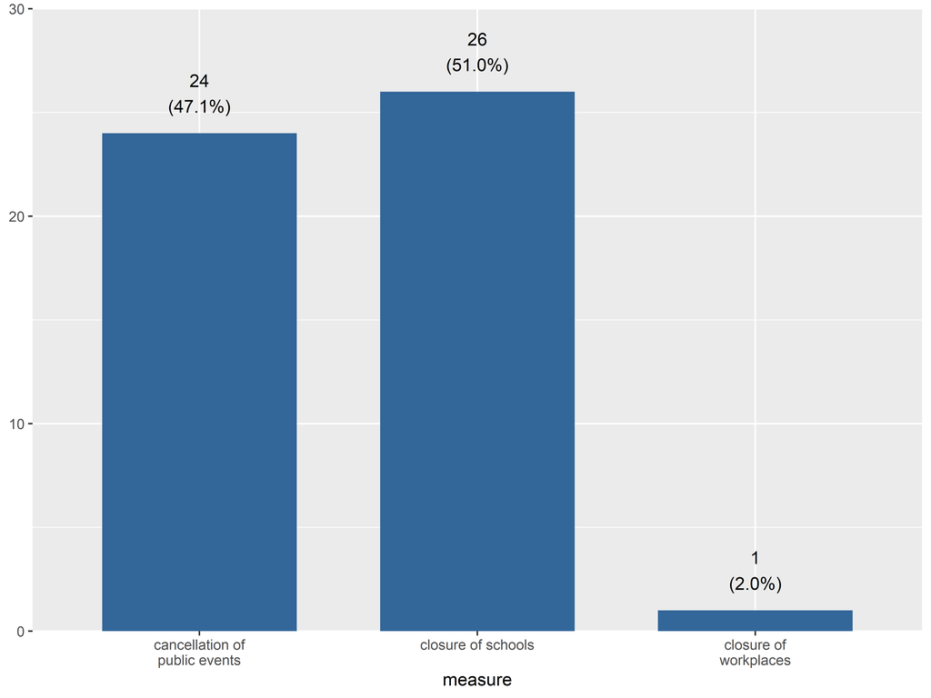

```r
# frq(measures, measure, sort.frq = "desc")
# plot_frq(measures, measure, coord.flip = TRUE)

# frq(measures, state)
# plot_frq(measures, state, coord.flip = TRUE)

measures %>%
  filter(date >= as.Date("2020-03-10") & date<= as.Date("2020-03-27")) %>%
  group_by(state) %>%
  arrange(date) %>%
  filter(row_number() == 1) %>%
  ungroup() %>%
  plot_frq(measure)
```

```r
write_rds(measures, "data/supplement/measures.Rds")
write_csv(measures, "data/supplement/measures.csv")

rm(measures_4, measures_5_10, measures_8, measures_11)
```

# 2 NYT Covid-19 data

The New York Times’ [Coronavirus (Covid-19) Data in the United States](https://github.com/nytimes/covid-19-data/) repository containing

> a series of data files with cumulative counts of coronavirus cases in the United States, at the state and county level, over time.

```r
urlfile="https://raw.githubusercontent.com/nytimes/covid-19-data/master/us-states.csv"

nyt_raw <- read_csv(url(urlfile))

# sjmisc::frq(nyt_raw, state)

write_rds(nyt_raw, "data-raw/nyt/nyt_raw.Rds")
write_csv(nyt_raw, "data-raw/nyt/nyt_raw.csv")
```

Raw dataset downloaded on 21 November, 2020 consists of 14,479 records of 55 states from 2020-01-21 to 2020-11-20.

Data are first limited to the 50 states plus DC - that was achieved by excluding `fips` codes `66, 69, 72, 78` for Guam, Northern Mariana Islands, Puerto Rico and Virgin Islands.

```r
nyt_raw %>%
  filter(fips %in% c(66, 69, 72, 78)) %>%
  group_by(state, fips) %>%
  summarise(records = n(),
            cases = sum(cases),
            deaths = sum(deaths)) %>%
  kbl() %>%
  kable_styling(bootstrap_options = c("striped", "hover", full_width = FALSE))
```

| state | fips | records | cases | deaths |
| --- | --- | --- | --- | --- |
| Guam | 66 | 251 | 541450 | 5652 |
| Northern Mariana Islands | 69 | 238 | 10914 | 462 |
| Puerto Rico | 72 | 253 | 5854608 | 83248 |
| Virgin Islands | 78 | 252 | 144616 | 2565 |

Next, data is limited to match the time frame of the analysis ie. until `2020-03-30` and daily number of cases are derived from cumulative counts. Next cases from previous day are added to each observation and logarithms and their difference are calculated. Finally only days when cumulative number of cases reached 30 are kept in the dataset.

```r
nyt <- nyt_raw %>%
  filter(!fips %in% c(66, 69, 72, 78)) %>%
  select(-fips, -deaths) %>%
  rename(cases_cumulative = cases) %>%
  filter(date <= as.Date("2020-03-30")) %>%
  arrange(state, date) %>%
  group_by(state) %>%
  mutate(cases_day = cases_cumulative - lag(cases_cumulative)) %>%
  mutate(cases_day = ifelse(is.na(cases_day), cases_cumulative, cases_day)) %>%
  mutate(cases_day_perc = ((cases_day - lag(cases_day))/ lag(cases_day)) *100,
         cases_daybefore = lag(cases_day)) %>%
  ungroup() %>%
  mutate(cases_day_ln = log(cases_day),
         cases_daybefore_ln = log(cases_daybefore),
         log_dif = cases_day_ln - cases_daybefore_ln) %>%
  filter(cases_cumulative >= 30) %>%
  arrange(state, date)
```

Prepared dataset consists of 770 records of 51 states from 2020-03-01 to 2020-03-30 period.

```r
write_rds(nyt, "data/nyt/nyt.Rds")
write_csv(nyt, "data/nyt/nyt.csv")
rm(nyt_raw)
```

Frequency of records by state:

```r
# length(unique(nyt$state))
# frq(nyt, state)
nyt %>%
  group_by(state) %>%
  summarize(records = n()) %>%
  kbl() %>%
  kable_styling(bootstrap_options = c("striped", "hover", full_width = FALSE))
```

| state | records |
| --- | --- |
| Alabama | 14 |
| Alaska | 8 |
| Arizona | 12 |
| Arkansas | 13 |
| California | 30 |
| Colorado | 20 |
| Connecticut | 15 |
| Delaware | 12 |
| District of Columbia | 14 |
| Florida | 19 |
| Georgia | 20 |
| Hawaii | 11 |
| Idaho | 11 |
| Illinois | 19 |
| Indiana | 14 |
| Iowa | 13 |
| Kansas | 12 |
| Kentucky | 13 |
| Louisiana | 18 |
| Maine | 14 |
| Maryland | 16 |
| Massachusetts | 22 |
| Michigan | 17 |
| Minnesota | 16 |
| Mississippi | 13 |
| Missouri | 12 |
| Montana | 9 |
| Nebraska | 16 |
| Nevada | 15 |
| New Hampshire | 13 |
| New Jersey | 18 |
| New Mexico | 12 |
| New York | 25 |
| North Carolina | 16 |
| North Dakota | 9 |
| Ohio | 16 |
| Oklahoma | 12 |
| Oregon | 19 |
| Pennsylvania | 18 |
| Rhode Island | 13 |
| South Carolina | 15 |
| South Dakota | 7 |
| Tennessee | 17 |
| Texas | 21 |
| Utah | 15 |
| Vermont | 10 |
| Virginia | 18 |
| Washington | 28 |
| West Virginia | 7 |
| Wisconsin | 16 |
| Wyoming | 7 |

And by date:

```r
# length(unique(nyt$date))
# frq(nyt, date)
nyt %>%
  group_by(date) %>%
  summarize(records = n()) %>%
  kbl() %>%
  kable_styling(bootstrap_options = c("striped", "hover", full_width = FALSE))
```

| date | records |
| --- | --- |
| 2020-03-01 | 1 |
| 2020-03-02 | 1 |
| 2020-03-03 | 2 |
| 2020-03-04 | 2 |
| 2020-03-05 | 2 |
| 2020-03-06 | 3 |
| 2020-03-07 | 3 |
| 2020-03-08 | 3 |
| 2020-03-09 | 4 |
| 2020-03-10 | 5 |
| 2020-03-11 | 7 |
| 2020-03-12 | 10 |
| 2020-03-13 | 14 |
| 2020-03-14 | 16 |
| 2020-03-15 | 22 |
| 2020-03-16 | 26 |
| 2020-03-17 | 30 |
| 2020-03-18 | 36 |
| 2020-03-19 | 42 |
| 2020-03-20 | 44 |
| 2020-03-21 | 45 |
| 2020-03-22 | 47 |
| 2020-03-23 | 48 |
| 2020-03-24 | 51 |
| 2020-03-25 | 51 |
| 2020-03-26 | 51 |
| 2020-03-27 | 51 |
| 2020-03-28 | 51 |
| 2020-03-29 | 51 |
| 2020-03-30 | 51 |

Missing and `Inf` data situation

```r
sapply(nyt, function(x) sum(is.na(x)))
```

```
##               date              state   cases_cumulative          cases_day
##                  0                  0                  0                  0
##     cases_day_perc    cases_daybefore       cases_day_ln cases_daybefore_ln
##                  0                  0                  0                  0
##            log_dif
##                  0
```

```r
sapply(nyt, function(x) sum(is.nan(x)))
```

```
##               date              state   cases_cumulative          cases_day
##                  0                  0                  0                  0
##     cases_day_perc    cases_daybefore       cases_day_ln cases_daybefore_ln
##                  0                  0                  0                  0
##            log_dif
##                  0
```

```r
sapply(nyt, function(x) sum(is.infinite(x)))
```

```
##               date              state   cases_cumulative          cases_day
##                  0                  0                  0                  0
##     cases_day_perc    cases_daybefore       cases_day_ln cases_daybefore_ln
##                  7                  0                  5                  7
##            log_dif
##                 12
```

```r
nyt %>%
  filter(is.infinite(log_dif)) %>%
  select(date, state, cases_day, cases_daybefore, log_dif) %>%
  kbl() %>%
  kable_styling(bootstrap_options = c("striped", "hover", full_width = FALSE))
```

| date | state | cases_day | cases_daybefore | log_dif |
| --- | --- | --- | --- | --- |
| 2020-03-18 | Arkansas | 11 | 0 | Inf |
| 2020-03-14 | Florida | 0 | 24 | -Inf |
| 2020-03-15 | Florida | 39 | 0 | Inf |
| 2020-03-12 | Georgia | 0 | 9 | -Inf |
| 2020-03-13 | Georgia | 10 | 0 | Inf |
| 2020-03-21 | Nevada | 0 | 66 | -Inf |
| 2020-03-22 | Nevada | 25 | 0 | Inf |
| 2020-03-13 | Oregon | 0 | 10 | -Inf |
| 2020-03-14 | Oregon | 6 | 0 | Inf |
| 2020-03-20 | Rhode Island | 0 | 11 | -Inf |
| 2020-03-21 | Rhode Island | 22 | 0 | Inf |
| 2020-03-24 | West Virginia | 23 | 0 | Inf |

# 3 Link of measures & cases datasets

## 3.1 First measure

```r
measures_first <- measures %>%
  select(-measure_short) %>%
  group_by(state) %>%
  arrange(date) %>%
  slice(1) %>%
  rename(date_first = date)

measures_first %>%
  kbl() %>%
  kable_styling(bootstrap_options = c("striped", "hover", full_width = FALSE))
```

| state | date_first | measure |
| --- | --- | --- |
| Alabama | 2020-03-18 | closure of schools |
| Alaska | 2020-03-14 | cancellation of public events |
| Arizona | 2020-03-16 | closure of schools |
| Arkansas | 2020-03-19 | closure of schools |
| California | 2020-03-11 | cancellation of public events |
| Colorado | 2020-03-17 | cancellation of public events |
| Connecticut | 2020-03-12 | cancellation of public events |
| Delaware | 2020-03-16 | closure of schools |
| District of Columbia | 2020-03-13 | cancellation of public events |
| Florida | 2020-03-16 | closure of schools |
| Georgia | 2020-03-18 | closure of schools |
| Hawaii | 2020-03-15 | closure of schools |
| Idaho | 2020-03-25 | closure of schools |
| Illinois | 2020-03-13 | cancellation of public events |
| Indiana | 2020-03-16 | cancellation of public events |
| Iowa | 2020-03-17 | cancellation of public events |
| Kansas | 2020-03-17 | closure of schools |
| Kentucky | 2020-03-18 | cancellation of public events |
| Louisiana | 2020-03-13 | closure of schools |
| Maine | 2020-03-18 | cancellation of public events |
| Maryland | 2020-03-12 | cancellation of public events |
| Massachusetts | 2020-03-13 | cancellation of public events |
| Michigan | 2020-03-16 | closure of schools |
| Minnesota | 2020-03-17 | cancellation of public events |
| Mississippi | 2020-03-19 | closure of schools |
| Missouri | 2020-03-17 | cancellation of public events |
| Montana | 2020-03-16 | closure of schools |
| Nebraska | 2020-03-16 | cancellation of public events |
| Nevada | 2020-03-16 | closure of schools |
| New Hampshire | 2020-03-16 | closure of schools |
| New Jersey | 2020-03-16 | cancellation of public events |
| New Mexico | 2020-03-16 | closure of schools |
| New York | 2020-03-16 | cancellation of public events |
| North Carolina | 2020-03-16 | closure of schools |
| North Dakota | 2020-03-16 | closure of schools |
| Ohio | 2020-03-15 | cancellation of public events |
| Oklahoma | 2020-03-17 | closure of schools |
| Oregon | 2020-03-16 | cancellation of public events |
| Pennsylvania | 2020-03-16 | closure of schools |
| Rhode Island | 2020-03-17 | cancellation of public events |
| South Carolina | 2020-03-16 | closure of schools |
| South Dakota | 2020-03-23 | cancellation of public events |
| Tennessee | 2020-03-20 | closure of schools |
| Texas | 2020-03-20 | closure of schools |
| Utah | 2020-03-16 | closure of schools |
| Vermont | 2020-03-13 | cancellation of public events |
| Virginia | 2020-03-12 | closure of workplaces |
| Washington | 2020-03-10 | cancellation of public events |
| West Virginia | 2020-03-13 | closure of schools |
| Wisconsin | 2020-03-17 | cancellation of public events |
| Wyoming | 2020-03-19 | closure of schools |

```r
nyt_first <- left_join(nyt, measures_first) %>%
  mutate(time_to_intervention = as.numeric(date - date_first),
         post_intervention = ifelse(time_to_intervention <= 3, 0, 1)) %>%
  arrange(state, time_to_intervention)
```

Prepared dataset consists of 770 records of 51 states from 2020-03-01 to 2020-03-30 period.

```r
str(nyt_first)
```

```
## tibble [770 x 13] (S3: tbl_df/tbl/data.frame)
##  $ date                : Date[1:770], format: "2020-03-17" "2020-03-18" ...
##  $ state               : chr [1:770] "Alabama" "Alabama" "Alabama" "Alabama" ...
##  $ cases_cumulative    : num [1:770] 39 51 78 106 131 157 196 242 386 538 ...
##  $ cases_day           : num [1:770] 10 12 27 28 25 26 39 46 144 152 ...
##  $ cases_day_perc      : num [1:770] 66.7 20 125 3.7 -10.7 ...
##  $ cases_daybefore     : num [1:770] 6 10 12 27 28 25 26 39 46 144 ...
##  $ cases_day_ln        : num [1:770] 2.3 2.48 3.3 3.33 3.22 ...
##  $ cases_daybefore_ln  : num [1:770] 1.79 2.3 2.48 3.3 3.33 ...
##  $ log_dif             : num [1:770] 0.5108 0.1823 0.8109 0.0364 -0.1133 ...
##  $ date_first          : Date[1:770], format: "2020-03-18" "2020-03-18" ...
##  $ measure             : chr [1:770] "closure of schools" "closure of schools" "closure of schools" "closure of schools" ...
##  $ time_to_intervention: num [1:770] -1 0 1 2 3 4 5 6 7 8 ...
##  $ post_intervention   : num [1:770] 0 0 0 0 0 1 1 1 1 1 ...
```

Example of first state:

```r
nyt_first %>%
  filter(state == "Alabama") %>%
  select(date, state, log_dif,
         date_first, time_to_intervention, post_intervention) %>%
  kbl() %>%
  kable_styling(bootstrap_options = c("striped", "hover", full_width = FALSE))
```

| date | state | log_dif | date_first | time_to_intervention | post_intervention |
| --- | --- | --- | --- | --- | --- |
| 2020-03-17 | Alabama | 0.5108256 | 2020-03-18 | -1 | 0 |
| 2020-03-18 | Alabama | 0.1823216 | 2020-03-18 | 0 | 0 |
| 2020-03-19 | Alabama | 0.8109302 | 2020-03-18 | 1 | 0 |
| 2020-03-20 | Alabama | 0.0363676 | 2020-03-18 | 2 | 0 |
| 2020-03-21 | Alabama | -0.1133287 | 2020-03-18 | 3 | 0 |
| 2020-03-22 | Alabama | 0.0392207 | 2020-03-18 | 4 | 1 |
| 2020-03-23 | Alabama | 0.4054651 | 2020-03-18 | 5 | 1 |
| 2020-03-24 | Alabama | 0.1650798 | 2020-03-18 | 6 | 1 |
| 2020-03-25 | Alabama | 1.1411719 | 2020-03-18 | 7 | 1 |
| 2020-03-26 | Alabama | 0.0540672 | 2020-03-18 | 8 | 1 |
| 2020-03-27 | Alabama | -0.4087600 | 2020-03-18 | 9 | 1 |
| 2020-03-28 | Alabama | -0.2206714 | 2020-03-18 | 10 | 1 |
| 2020-03-29 | Alabama | 0.3060312 | 2020-03-18 | 11 | 1 |
| 2020-03-30 | Alabama | 0.0616936 | 2020-03-18 | 12 | 1 |

Median & IQR size of epidemic when measure was implemented

```r
nyt_first %>%
  filter(date == date_first) %>%
  summarise(median = median(cases_cumulative),
            p25 = quantile(cases_cumulative, prob = 0.25),
            p75 = quantile(cases_cumulative, prob = 0.75))
```

```
## # A tibble: 1 x 3
##   median   p25   p75
##    <dbl> <dbl> <dbl>
## 1     60    43   176
```

Mean size of epidemic growth

```r
nyt_first %>%
  filter(date == date_first) %>%
  summarise(mean = mean(cases_day_perc))
```

```
## # A tibble: 1 x 1
##    mean
##   <dbl>
## 1  129.
```

```r
write_rds(nyt_first, "data/nyt_first.Rds")
write_csv(nyt_first, "data/nyt_first.csv")
```

## 3.2 Lockdown

Not all states implemented that!

```r
measures_lockdown <- measures %>%
  filter(measure == "restrictions on internal movement") %>%
  select(-measure_short) %>%
  rename(date_lockdown = date)

measures_lockdown %>%
  kbl() %>%
  kable_styling(bootstrap_options = c("striped", "hover", full_width = FALSE))
```

| state | date_lockdown | measure |
| --- | --- | --- |
| Alaska | 2020-03-28 | restrictions on internal movement |
| Arizona | 2020-03-31 | restrictions on internal movement |
| California | 2020-03-19 | restrictions on internal movement |
| Connecticut | 2020-03-23 | restrictions on internal movement |
| Delaware | 2020-03-24 | restrictions on internal movement |
| District of Columbia | 2020-04-01 | restrictions on internal movement |
| Georgia | 2020-03-24 | restrictions on internal movement |
| Hawaii | 2020-03-25 | restrictions on internal movement |
| Idaho | 2020-03-25 | restrictions on internal movement |
| Illinois | 2020-03-21 | restrictions on internal movement |
| Indiana | 2020-03-24 | restrictions on internal movement |
| Kansas | 2020-03-30 | restrictions on internal movement |
| Louisiana | 2020-03-23 | restrictions on internal movement |
| Maryland | 2020-03-30 | restrictions on internal movement |
| Massachusetts | 2020-03-24 | restrictions on internal movement |
| Michigan | 2020-03-24 | restrictions on internal movement |
| Minnesota | 2020-03-27 | restrictions on internal movement |
| Montana | 2020-03-28 | restrictions on internal movement |
| New Hampshire | 2020-03-27 | restrictions on internal movement |
| New Jersey | 2020-03-21 | restrictions on internal movement |
| New Mexico | 2020-03-24 | restrictions on internal movement |
| New York | 2020-03-22 | restrictions on internal movement |
| North Carolina | 2020-03-30 | restrictions on internal movement |
| Ohio | 2020-03-23 | restrictions on internal movement |
| Oklahoma | 2020-03-25 | restrictions on internal movement |
| Oregon | 2020-03-23 | restrictions on internal movement |
| Rhode Island | 2020-03-30 | restrictions on internal movement |
| Vermont | 2020-03-25 | restrictions on internal movement |
| Virginia | 2020-03-30 | restrictions on internal movement |
| Washington | 2020-03-23 | restrictions on internal movement |
| West Virginia | 2020-03-24 | restrictions on internal movement |
| Wisconsin | 2020-03-25 | restrictions on internal movement |

```r
nyt_lockdown <- left_join(nyt, measures_lockdown) %>%
  mutate(date_lockdown_filled = if_else(is.na(date_lockdown), as.Date("2020-03-30"), date_lockdown)) %>%
  mutate(time_to_lockdown = as.numeric(date - date_lockdown_filled),
         post_intervention = ifelse(time_to_lockdown <= 3, 0, 1)) %>%
  arrange(state, time_to_lockdown)
```

Prepared dataset consists of 770 records of 51 states from 2020-03-01 to 2020-03-30 period.

```r
str(nyt_first)
```

```
## tibble [770 x 13] (S3: tbl_df/tbl/data.frame)
##  $ date                : Date[1:770], format: "2020-03-17" "2020-03-18" ...
##  $ state               : chr [1:770] "Alabama" "Alabama" "Alabama" "Alabama" ...
##  $ cases_cumulative    : num [1:770] 39 51 78 106 131 157 196 242 386 538 ...
##  $ cases_day           : num [1:770] 10 12 27 28 25 26 39 46 144 152 ...
##  $ cases_day_perc      : num [1:770] 66.7 20 125 3.7 -10.7 ...
##  $ cases_daybefore     : num [1:770] 6 10 12 27 28 25 26 39 46 144 ...
##  $ cases_day_ln        : num [1:770] 2.3 2.48 3.3 3.33 3.22 ...
##  $ cases_daybefore_ln  : num [1:770] 1.79 2.3 2.48 3.3 3.33 ...
##  $ log_dif             : num [1:770] 0.5108 0.1823 0.8109 0.0364 -0.1133 ...
##  $ date_first          : Date[1:770], format: "2020-03-18" "2020-03-18" ...
##  $ measure             : chr [1:770] "closure of schools" "closure of schools" "closure of schools" "closure of schools" ...
##  $ time_to_intervention: num [1:770] -1 0 1 2 3 4 5 6 7 8 ...
##  $ post_intervention   : num [1:770] 0 0 0 0 0 1 1 1 1 1 ...
```

Example of one state:

```r
nyt_lockdown %>%
  filter(state == "Connecticut") %>%
  select(date, state, log_dif,
         date_lockdown_filled, time_to_lockdown, post_intervention) %>%
  kbl() %>%
  kable_styling(bootstrap_options = c("striped", "hover", full_width = FALSE))
```

| date | state | log_dif | date_lockdown_filled | time_to_lockdown | post_intervention |
| --- | --- | --- | --- | --- | --- |
| 2020-03-16 | Connecticut | 0.9162907 | 2020-03-23 | -7 | 0 |
| 2020-03-17 | Connecticut | 0.5877867 | 2020-03-23 | -6 | 0 |
| 2020-03-18 | Connecticut | 0.0363676 | 2020-03-23 | -5 | 0 |
| 2020-03-19 | Connecticut | 0.8109302 | 2020-03-23 | -4 | 0 |
| 2020-03-20 | Connecticut | -0.5877867 | 2020-03-23 | -3 | 0 |
| 2020-03-21 | Connecticut | -0.1880522 | 2020-03-23 | -2 | 0 |
| 2020-03-22 | Connecticut | 1.2770951 | 2020-03-23 | -1 | 0 |
| 2020-03-23 | Connecticut | -0.1670541 | 2020-03-23 | 0 | 0 |
| 2020-03-24 | Connecticut | 0.8358692 | 2020-03-23 | 1 | 0 |
| 2020-03-25 | Connecticut | 0.2358701 | 2020-03-23 | 2 | 0 |
| 2020-03-26 | Connecticut | -0.6290952 | 2020-03-23 | 3 | 0 |
| 2020-03-27 | Connecticut | 0.7112309 | 2020-03-23 | 4 | 1 |
| 2020-03-28 | Connecticut | -0.1801733 | 2020-03-23 | 5 | 1 |
| 2020-03-29 | Connecticut | 0.6995643 | 2020-03-23 | 6 | 1 |
| 2020-03-30 | Connecticut | 0.2089711 | 2020-03-23 | 7 | 1 |

Median & IQR size of epidemic when measure was implemented

```r
nyt_lockdown %>%
  filter(date == as.Date("2020-03-30")) %>%
  summarise(median = median(cases_cumulative),
            p25 = quantile(cases_cumulative, prob = 0.25),
            p75 = quantile(cases_cumulative, prob = 0.75))
```

```
## # A tibble: 1 x 3
##   median   p25   p75
##    <dbl> <dbl> <dbl>
## 1    925   344 2600.
```

Mean size of epidemic growth

```r
nyt_lockdown %>%
  filter(date == as.Date("2020-03-30")) %>%
  summarise(mean = mean(cases_day_perc))
```

```
## # A tibble: 1 x 1
##    mean
##   <dbl>
## 1  30.2
```

```r
write_rds(nyt_lockdown, "data/nyt_lockdown.Rds")
write_csv(nyt_lockdown, "data/nyt_lockdown.csv")
```

# 4 Pop density

## 4.1 Numerator

Data comes from *State Population Totals and Components of Change: 2010-2019* [website](https://www.census.gov/data/tables/time-series/demo/popest/2010s-state-total.html#par_textimage_1574439295) of the US Census Bureau.

Specifically dataset is extracted from the spreadsheet `Annual Estimates of the Resident Population for the United States, Regions, States, and Puerto Rico: April 1, 2010 to July 1, 2019 (NST-EST2019-01)` fount in the section *Population, Population Change, and Estimated Components of Population Change: April 1, 2010 to July 1, 2019 (NST-EST2019-alldata)*.

```r
population <- read_excel("data-raw/census/nst-est2019-01.xlsx",
                         skip = 3) %>%
  clean_names() %>%
  remove_empty() %>%
  rename(state = x1,
         pop_2019 = x2019) %>%
  select(state, pop_2019) %>%
  filter(! state %in% c("United States", "Northeast", "Midwest", "South", "West"),
         !is.na(pop_2019)) %>%
  mutate(state = str_replace(state, fixed("."), ""))

population %>%
  slice(1:5) %>%
  kbl() %>%
  kable_styling(bootstrap_options = c("striped", "hover", full_width = FALSE))
```

| state | pop_2019 |
| --- | --- |
| Alabama | 4903185 |
| Alaska | 731545 |
| Arizona | 7278717 |
| Arkansas | 3017804 |
| California | 39512223 |

```r
write_rds(population, "data/census/population.Rds")
write_csv(population, "data/census/population.csv")
```

## 4.2 Denominator

Data comes from *State Area Measurements and Internal Point Coordinates* [website](https://www.census.gov/geographies/reference-files/2010/geo/state-area.html) of the US Census Bureau. No download was avaialble so table was scraped using `rvest` package.

```r
p_load(rvest)

webpage <- read_html("https://www.census.gov/geographies/reference-files/2010/geo/state-area.html")

# html_nodes(webpage, "table")

area <- webpage %>%
  html_nodes("table") %>%
  .[1] %>%
  html_table(fill = TRUE) %>%
  .[[1]] %>%
  clean_names() %>%
  remove_empty() %>%
  as_tibble() %>%
  rename(state = state_and_other_areas2) %>%
  filter(state != "State and other areas2",
         state != "Total3",
         state != "United States4",
         state != "") %>%
  select(state, total_area, total_area_2, land_area1, land_area1_2) %>%
  rename(total_area_km = total_area,
         total_area_mi = total_area_2,
         land_area_km = land_area1,
         land_area_mi = land_area1_2)

area %>%
  slice(1:5) %>%
  kbl() %>%
  kable_styling(bootstrap_options = c("striped", "hover", full_width = FALSE))
```

| state | total_area_km | total_area_mi | land_area_km | land_area_mi |
| --- | --- | --- | --- | --- |
| Alabama | 52,420 | 135,767 | 50,645 | 131,171 |
| Alaska | 665,384 | 1,723,337 | 570,641 | 1,477,953 |
| Arizona | 113,990 | 295,234 | 113,594 | 294,207 |
| Arkansas | 53,179 | 137,732 | 52,035 | 134,771 |
| California | 163,695 | 423,967 | 155,779 | 403,466 |

```r
write_rds(area, "data/census/area.Rds")
write_csv(area, "data/census/area.csv")
```